# Sensitivity analysis

Lawson et al

2023-06-20

# Sensitivity analysis

## A. Load parameters for baseline

## B. Define the parameters for sensitivity analysis

```
## [1] "There are 1604 combinations to test"
```

## C. Define function to run model

In this section, I have not yet perfected the outputs of the models. I think it might be good to keep it like that, and then to define a second function to track the equilibrium outputs. So far, the functions return the equilibrium values of the stock. A second module (maybe tomorrow) will compute :

- Equilibrium farmed and harvested quantities
- Prices paid to poachers
- Profits

## D. Run

To deal with data, there are two layers :

- Column `spec` displays which variable has been tweaked. For example, if one wants to analyze data for changed values of `v`, run `store %>% subset(spec == 'v')`, or when $c$ and $v$ move at the same time, `store %>% subset(spec == 'c and v')`.
- Second, column `transformation` can be used to color the graphs. If you want to check what how different values of `v` may impact the results, you can subset based on `transformation`. To find where each was applied, check section B’s code

# Sensitivity graphs

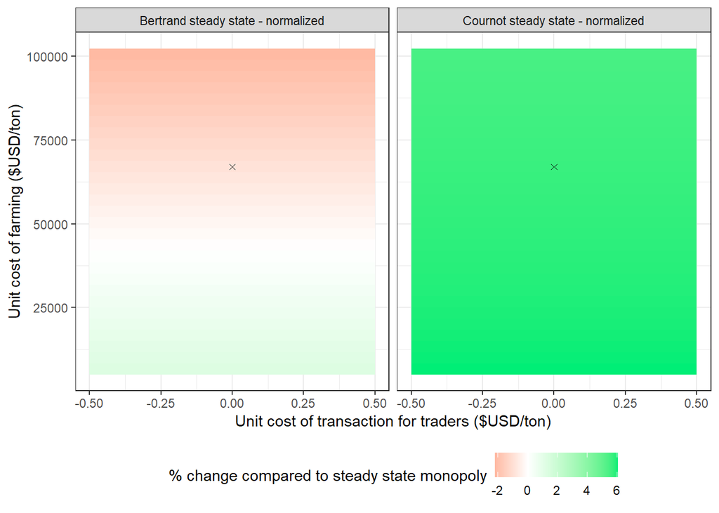

```
##    Min. 1st Qu.  Median    Mean 3rd Qu.    Max.    NA's
##      NA      NA      NA     NaN      NA      NA     400
```

```
##    Min. 1st Qu.  Median    Mean 3rd Qu.    Max.    NA's
##      NA      NA      NA     NaN      NA      NA     400
```

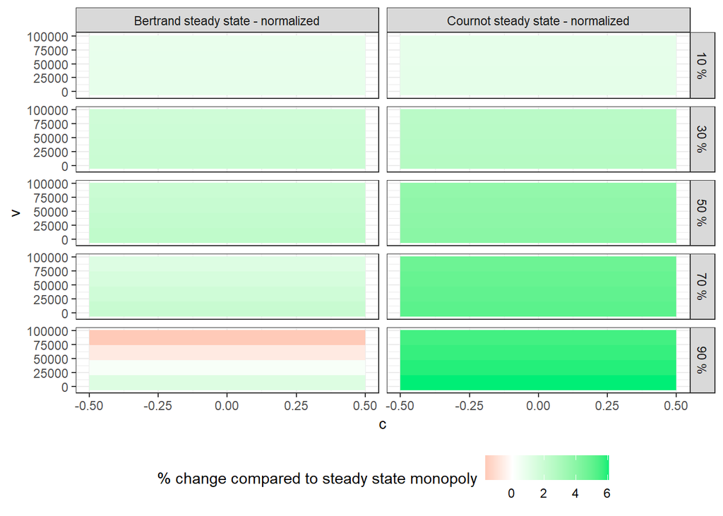

## Other analysis

### What demand increase would be needed to offset the positive effects of competition?

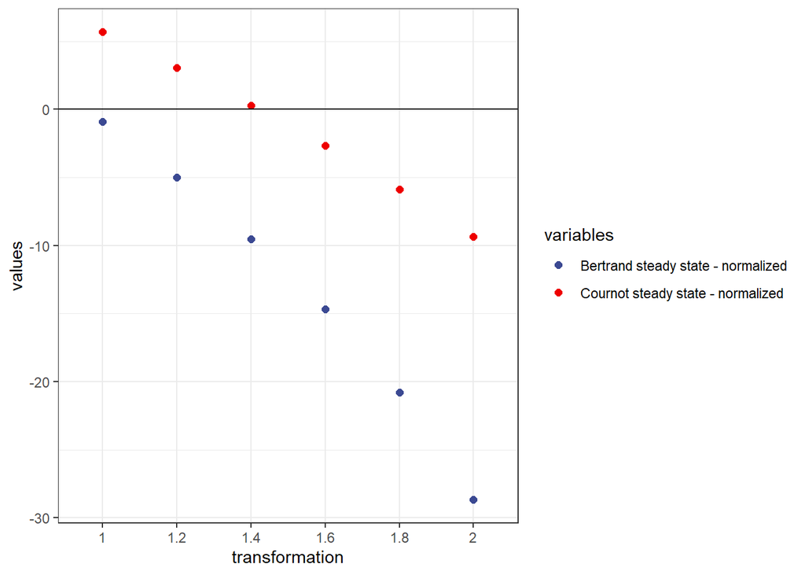

### How do results evolve with substitutability?

| gamma | transformation | Cournot normalized | Bertrand normalized |
| --- | --- | --- | --- |
| 0.1407376 | 0.0001 | 0.00 | 0.00 |
| 14.0737643 | 0.01 | 0.09 | 0.09 |
| 156.3751593 | 0.111111111111111 | 0.94 | 0.85 |
| 312.7503185 | 0.222222222222222 | 1.78 | 1.44 |
| 781.8757963 | 0.555555555555555 | 3.80 | 2.02 |
| 1251.0012741 | 0.888888888888888 | 5.28 | 0.69 |
| 1407.3764334 | 1 | 5.68 | -0.92 |
| 1485.5640130 | 1.05555555555555 | 5.86 | -3.21 |
| 1563.5952175 | 1.111 | 6.03 | -27.30 |